# Developing Data Products - Final Project Presentation

# Introduction

- This document briefly describes the Shiny web application used to discover the changes in population of four groups of British wild birds in the period 1975 to 2014.
- The data is from ‘Wild Bird Populations in the UK’ (publsihed by the Uk Government). For the source webapge - including notes on dataset and the dataset for download - click here: [Link to data.gov.uk](https://data.gov.uk/dataset/wild_bird_populations/resource/16bcd620-c404-47ed-8cda-5315b24bf0c5)
- Notes for the data processing can be found in the file: uk-bird-data-4-groups.R. This file can be viewed in the github repository for this project: [Link to github](https://github.com/AledEvansUK/Coursera-Dev-Data-Products)

# The Application

The bird population numbers selected using the ‘selectInput’ dropdown input.

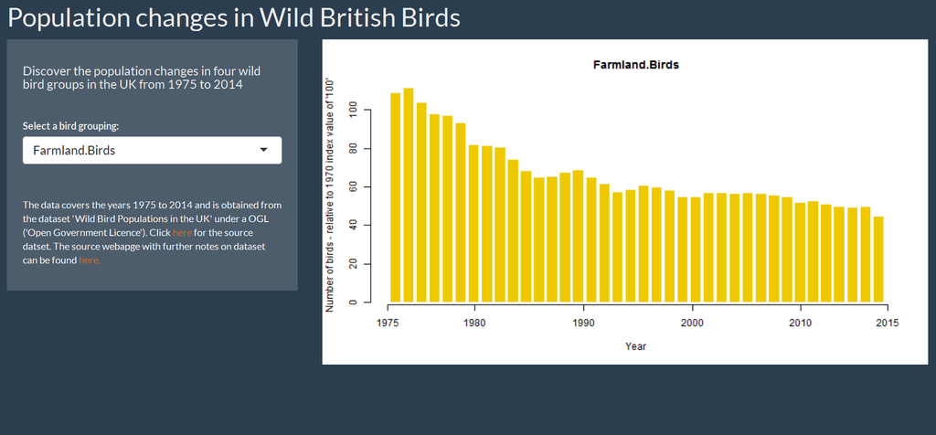

# R code for the plot

output$plot1 <- renderPlot({ birdtype = input$birdtype barplot(birdData[, birdtype], main = birdtype, ylab=“Number of birds - relative to 1970 index value of ‘100’”, xlab=“Year”, col=“gold2”, border=“white”, xaxt = “n”) axis(side=1, at=c(0, 8, 18, 28, 38, 46), labels=c(“1975”,“1980”,“1990”,“2000”, “2010”, “2015”)) })

[output not shown]